# Risk Factor Analysis

## Outcome Variable

**Outcome Variable:** y_rate_haz

## Predictor Variables

**Intervention Variable:** nrooms

**Adjustment Set:**

- arm
- sex
- W_mage
- meducyrs
- feducyrs
- hhwealth_quart
- hfoodsec
- W_mhtcm
- W_nchldlt5
- W_parity
- impfloor
- impsan
- safeh20
- delta_W_mage
- delta_meducyrs
- delta_feducyrs
- delta_hhwealth_quart
- delta_hfoodsec
- delta_W_mhtcm
- delta_W_nchldlt5
- delta_W_parity
- delta_impfloor
- delta_impsan
- delta_safeh20

## Stratifying Variables

The analysis was stratified on these variable(s):

- agecat
- studyid
- country

## Data Summary

| agecat | studyid | country | nrooms | n_cell | n |
| --- | --- | --- | --- | --- | --- |
| 0-3 months | ki0047075b-MAL-ED | BANGLADESH | 1 | 149 | 237 |
| 0-3 months | ki0047075b-MAL-ED | BANGLADESH | 2 | 49 | 237 |
| 0-3 months | ki0047075b-MAL-ED | BANGLADESH | 3 | 28 | 237 |
| 0-3 months | ki0047075b-MAL-ED | BANGLADESH | 4+ | 11 | 237 |
| 0-3 months | ki1017093b-PROVIDE | BANGLADESH | 1 | 452 | 634 |
| 0-3 months | ki1017093b-PROVIDE | BANGLADESH | 2 | 101 | 634 |
| 0-3 months | ki1017093b-PROVIDE | BANGLADESH | 3 | 59 | 634 |
| 0-3 months | ki1017093b-PROVIDE | BANGLADESH | 4+ | 22 | 634 |
| 0-3 months | ki1017093c-NIH-Crypto | BANGLADESH | 1 | 344 | 720 |
| 0-3 months | ki1017093c-NIH-Crypto | BANGLADESH | 2 | 183 | 720 |
| 0-3 months | ki1017093c-NIH-Crypto | BANGLADESH | 3 | 102 | 720 |
| 0-3 months | ki1017093c-NIH-Crypto | BANGLADESH | 4+ | 91 | 720 |
| 0-3 months | kiGH5241-JiVitA-3 | BANGLADESH | 1 | 12473 | 20026 |
| 0-3 months | kiGH5241-JiVitA-3 | BANGLADESH | 2 | 5183 | 20026 |
| 0-3 months | kiGH5241-JiVitA-3 | BANGLADESH | 3 | 1687 | 20026 |
| 0-3 months | kiGH5241-JiVitA-3 | BANGLADESH | 4+ | 683 | 20026 |
| 0-3 months | kiGH5241-JiVitA-4 | BANGLADESH | 1 | 1111 | 1805 |
| 0-3 months | kiGH5241-JiVitA-4 | BANGLADESH | 2 | 452 | 1805 |
| 0-3 months | kiGH5241-JiVitA-4 | BANGLADESH | 3 | 172 | 1805 |
| 0-3 months | kiGH5241-JiVitA-4 | BANGLADESH | 4+ | 70 | 1805 |
| 0-3 months | ki0047075b-MAL-ED | BRAZIL | 1 | 3 | 174 |
| 0-3 months | ki0047075b-MAL-ED | BRAZIL | 2 | 19 | 174 |
| 0-3 months | ki0047075b-MAL-ED | BRAZIL | 3 | 50 | 174 |
| 0-3 months | ki0047075b-MAL-ED | BRAZIL | 4+ | 102 | 174 |
| 0-3 months | ki0047075b-MAL-ED | INDIA | 1 | 73 | 194 |
| 0-3 months | ki0047075b-MAL-ED | INDIA | 2 | 68 | 194 |
| 0-3 months | ki0047075b-MAL-ED | INDIA | 3 | 31 | 194 |
| 0-3 months | ki0047075b-MAL-ED | INDIA | 4+ | 22 | 194 |
| 0-3 months | ki1000108-CMC-V-BCS-2002 | INDIA | 1 | 33 | 87 |
| 0-3 months | ki1000108-CMC-V-BCS-2002 | INDIA | 2 | 32 | 87 |

[output cut: 221 more lines]

The following strata were considered:

- agecat: 0-3 months, studyid: ki0047075b-MAL-ED, country: BANGLADESH
- agecat: 0-3 months, studyid: ki0047075b-MAL-ED, country: BRAZIL
- agecat: 0-3 months, studyid: ki0047075b-MAL-ED, country: INDIA
- agecat: 0-3 months, studyid: ki0047075b-MAL-ED, country: NEPAL
- agecat: 0-3 months, studyid: ki0047075b-MAL-ED, country: PERU
- agecat: 0-3 months, studyid: ki0047075b-MAL-ED, country: SOUTH AFRICA
- agecat: 0-3 months, studyid: ki0047075b-MAL-ED, country: TANZANIA, UNITED REPUBLIC OF
- agecat: 0-3 months, studyid: ki1000108-CMC-V-BCS-2002, country: INDIA
- agecat: 0-3 months, studyid: ki1000108-IRC, country: INDIA
- agecat: 0-3 months, studyid: ki1017093b-PROVIDE, country: BANGLADESH
- agecat: 0-3 months, studyid: ki1017093c-NIH-Crypto, country: BANGLADESH
- agecat: 0-3 months, studyid: ki1114097-CONTENT, country: PERU
- agecat: 0-3 months, studyid: ki1135781-COHORTS, country: INDIA
- agecat: 0-3 months, studyid: kiGH5241-JiVitA-3, country: BANGLADESH
- agecat: 0-3 months, studyid: kiGH5241-JiVitA-4, country: BANGLADESH
- agecat: 12-24 months, studyid: ki0047075b-MAL-ED, country: BANGLADESH
- agecat: 12-24 months, studyid: ki0047075b-MAL-ED, country: BRAZIL
- agecat: 12-24 months, studyid: ki0047075b-MAL-ED, country: INDIA
- agecat: 12-24 months, studyid: ki0047075b-MAL-ED, country: NEPAL
- agecat: 12-24 months, studyid: ki0047075b-MAL-ED, country: PERU
- agecat: 12-24 months, studyid: ki0047075b-MAL-ED, country: SOUTH AFRICA
- agecat: 12-24 months, studyid: ki0047075b-MAL-ED, country: TANZANIA, UNITED REPUBLIC OF
- agecat: 12-24 months, studyid: ki1000108-CMC-V-BCS-2002, country: INDIA
- agecat: 12-24 months, studyid: ki1000108-IRC, country: INDIA
- agecat: 12-24 months, studyid: ki1017093b-PROVIDE, country: BANGLADESH
- agecat: 12-24 months, studyid: ki1017093c-NIH-Crypto, country: BANGLADESH
- agecat: 12-24 months, studyid: ki1113344-GMS-Nepal, country: NEPAL
- agecat: 12-24 months, studyid: ki1114097-CONTENT, country: PERU
- agecat: 12-24 months, studyid: ki1135781-COHORTS, country: INDIA
- agecat: 12-24 months, studyid: kiGH5241-JiVitA-3, country: BANGLADESH
- agecat: 12-24 months, studyid: kiGH5241-JiVitA-4, country: BANGLADESH
- agecat: 3-6 months, studyid: ki0047075b-MAL-ED, country: BANGLADESH
- agecat: 3-6 months, studyid: ki0047075b-MAL-ED, country: BRAZIL
- agecat: 3-6 months, studyid: ki0047075b-MAL-ED, country: INDIA
- agecat: 3-6 months, studyid: ki0047075b-MAL-ED, country: NEPAL
- agecat: 3-6 months, studyid: ki0047075b-MAL-ED, country: PERU
- agecat: 3-6 months, studyid: ki0047075b-MAL-ED, country: SOUTH AFRICA
- agecat: 3-6 months, studyid: ki0047075b-MAL-ED, country: TANZANIA, UNITED REPUBLIC OF
- agecat: 3-6 months, studyid: ki1000108-CMC-V-BCS-2002, country: INDIA
- agecat: 3-6 months, studyid: ki1000108-IRC, country: INDIA
- agecat: 3-6 months, studyid: ki1017093b-PROVIDE, country: BANGLADESH
- agecat: 3-6 months, studyid: ki1017093c-NIH-Crypto, country: BANGLADESH
- agecat: 3-6 months, studyid: ki1113344-GMS-Nepal, country: NEPAL
- agecat: 3-6 months, studyid: ki1114097-CONTENT, country: PERU
- agecat: 3-6 months, studyid: ki1135781-COHORTS, country: INDIA
- agecat: 3-6 months, studyid: kiGH5241-JiVitA-3, country: BANGLADESH
- agecat: 3-6 months, studyid: kiGH5241-JiVitA-4, country: BANGLADESH
- agecat: 6-12 months, studyid: ki0047075b-MAL-ED, country: BANGLADESH
- agecat: 6-12 months, studyid: ki0047075b-MAL-ED, country: BRAZIL
- agecat: 6-12 months, studyid: ki0047075b-MAL-ED, country: INDIA
- agecat: 6-12 months, studyid: ki0047075b-MAL-ED, country: NEPAL
- agecat: 6-12 months, studyid: ki0047075b-MAL-ED, country: PERU
- agecat: 6-12 months, studyid: ki0047075b-MAL-ED, country: SOUTH AFRICA
- agecat: 6-12 months, studyid: ki0047075b-MAL-ED, country: TANZANIA, UNITED REPUBLIC OF
- agecat: 6-12 months, studyid: ki1000108-CMC-V-BCS-2002, country: INDIA
- agecat: 6-12 months, studyid: ki1000108-IRC, country: INDIA
- agecat: 6-12 months, studyid: ki1017093b-PROVIDE, country: BANGLADESH
- agecat: 6-12 months, studyid: ki1017093c-NIH-Crypto, country: BANGLADESH
- agecat: 6-12 months, studyid: ki1113344-GMS-Nepal, country: NEPAL
- agecat: 6-12 months, studyid: ki1114097-CONTENT, country: PERU
- agecat: 6-12 months, studyid: ki1135781-COHORTS, country: INDIA
- agecat: 6-12 months, studyid: kiGH5241-JiVitA-3, country: BANGLADESH
- agecat: 6-12 months, studyid: kiGH5241-JiVitA-4, country: BANGLADESH

### Dropped Strata

Some strata were dropped due to rare outcomes:

- agecat: 0-3 months, studyid: ki0047075b-MAL-ED, country: BRAZIL
- agecat: 0-3 months, studyid: ki1000108-CMC-V-BCS-2002, country: INDIA
- agecat: 0-3 months, studyid: ki1114097-CONTENT, country: PERU
- agecat: 3-6 months, studyid: ki0047075b-MAL-ED, country: BRAZIL
- agecat: 6-12 months, studyid: ki0047075b-MAL-ED, country: BRAZIL

## Methods Detail

We’re interested in the causal parameters $E[Y_a]$ for all values of $a \in \mathcal{A}$. These parameters represent the mean outcome if, possibly contrary to fact, we intervened to set all units to have $A=a$. Under the randomization and positivity assumptions, these are identified by the statistical parameters $\psi_a=E_W[E_{Y|A,W}(Y|A=a,W)]$. In addition, we’re interested in the mean of $Y$, $E[Y]$ under no intervention (the observed mean). We will estimate these parameters by using SuperLearner to fit the relevant likelihood factors – $E_{Y|A,W}(Y|A=a,W)$ and $p(A=a|W)$, and then updating our likelihood fit using a joint TMLE.

For unadjusted analyses ($W=\{\}$), initial likelihoods were estimated using Lrnr_glm to estimate the simple $E(Y|A)$ and Lrnr_mean to estimate $p(A)$. For adjusted analyses, a small library containing Lrnr_glmnet, Lrnr_xgboost, and Lrnr_mean was used.

Having estimated these parameters, we will then use the delta method to estimate relative risks and attributable risks relative to a prespecified baseline level of $A$.

[output not shown]

# Results Detail

## Results Plots

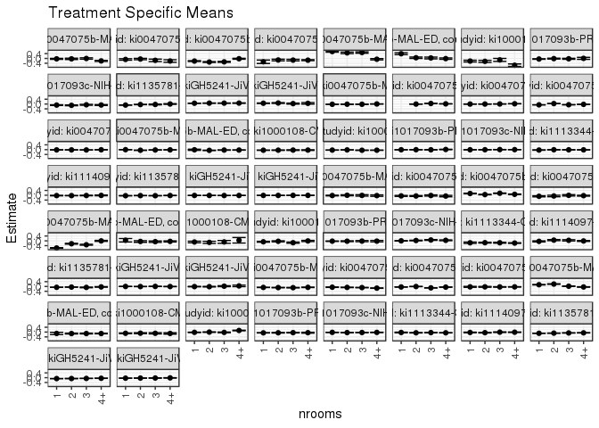

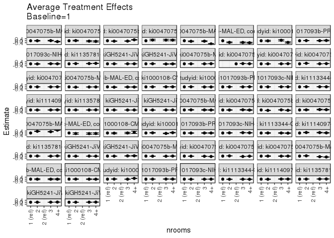

## Results Table

### Parameter: TSM

| agecat | studyid | country | intervention_level | baseline_level | estimate | ci_lower | ci_upper |
| --- | --- | --- | --- | --- | --- | --- | --- |
| 0-3 months | ki0047075b-MAL-ED | BANGLADESH | 1 | NA | -0.0342121 | -0.0747307 | 0.0063064 |
| 0-3 months | ki0047075b-MAL-ED | BANGLADESH | 2 | NA | -0.0341520 | -0.0892641 | 0.0209601 |
| 0-3 months | ki0047075b-MAL-ED | BANGLADESH | 3 | NA | -0.0052984 | -0.0631068 | 0.0525099 |
| 0-3 months | ki0047075b-MAL-ED | BANGLADESH | 4+ | NA | -0.2049548 | -0.2483919 | -0.1615177 |
| 0-3 months | ki0047075b-MAL-ED | INDIA | 1 | NA | -0.0838929 | -0.1459616 | -0.0218243 |
| 0-3 months | ki0047075b-MAL-ED | INDIA | 2 | NA | -0.0500442 | -0.1060406 | 0.0059522 |
| 0-3 months | ki0047075b-MAL-ED | INDIA | 3 | NA | -0.1582462 | -0.2603022 | -0.0561903 |
| 0-3 months | ki0047075b-MAL-ED | INDIA | 4+ | NA | -0.2136008 | -0.3170597 | -0.1101419 |
| 0-3 months | ki0047075b-MAL-ED | NEPAL | 1 | NA | -0.2192185 | -0.2516908 | -0.1867461 |
| 0-3 months | ki0047075b-MAL-ED | NEPAL | 2 | NA | -0.2985844 | -0.3316203 | -0.2655486 |
| 0-3 months | ki0047075b-MAL-ED | NEPAL | 3 | NA | -0.2840721 | -0.3205423 | -0.2476019 |
| 0-3 months | ki0047075b-MAL-ED | NEPAL | 4+ | NA | -0.0256979 | -0.0635745 | 0.0121787 |
| 0-3 months | ki0047075b-MAL-ED | PERU | 1 | NA | -0.2771435 | -0.4205423 | -0.1337447 |
| 0-3 months | ki0047075b-MAL-ED | PERU | 2 | NA | -0.1292892 | -0.1979590 | -0.0606194 |
| 0-3 months | ki0047075b-MAL-ED | PERU | 3 | NA | -0.1397319 | -0.2046745 | -0.0747894 |
| 0-3 months | ki0047075b-MAL-ED | PERU | 4+ | NA | -0.1442067 | -0.1842017 | -0.1042118 |
| 0-3 months | ki0047075b-MAL-ED | SOUTH AFRICA | 1 | NA | 0.5718986 | 0.5242720 | 0.6195251 |
| 0-3 months | ki0047075b-MAL-ED | SOUTH AFRICA | 2 | NA | 0.4623476 | 0.3976753 | 0.5270198 |
| 0-3 months | ki0047075b-MAL-ED | SOUTH AFRICA | 3 | NA | 0.4934281 | 0.4352227 | 0.5516336 |
| 0-3 months | ki0047075b-MAL-ED | SOUTH AFRICA | 4+ | NA | -0.0666186 | -0.1184973 | -0.0147399 |
| 0-3 months | ki0047075b-MAL-ED | TANZANIA, UNITED REPUBLIC OF | 1 | NA | 0.3902815 | 0.3146437 | 0.4659192 |
| 0-3 months | ki0047075b-MAL-ED | TANZANIA, UNITED REPUBLIC OF | 2 | NA | 0.0563586 | -0.0013412 | 0.1140584 |
| 0-3 months | ki0047075b-MAL-ED | TANZANIA, UNITED REPUBLIC OF | 3 | NA | 0.0391892 | -0.0341844 | 0.1125628 |
| 0-3 months | ki0047075b-MAL-ED | TANZANIA, UNITED REPUBLIC OF | 4+ | NA | -0.0144602 | -0.0704039 | 0.0414836 |
| 0-3 months | ki1000108-IRC | INDIA | 1 | NA | -0.2202036 | -0.2925291 | -0.1478780 |
| 0-3 months | ki1000108-IRC | INDIA | 2 | NA | -0.2420017 | -0.3275841 | -0.1564193 |
| 0-3 months | ki1000108-IRC | INDIA | 3 | NA | -0.1222838 | -0.2452596 | 0.0006920 |
| 0-3 months | ki1000108-IRC | INDIA | 4+ | NA | -0.5649364 | -0.6704840 | -0.4593887 |
| 0-3 months | ki1017093b-PROVIDE | BANGLADESH | 1 | NA | -0.0492851 | -0.0701200 | -0.0284503 |
| 0-3 months | ki1017093b-PROVIDE | BANGLADESH | 2 | NA | -0.0156820 | -0.0510347 | 0.0196706 |

[output cut: 201 more lines]

### Parameter: E(Y)

| agecat | studyid | country | intervention_level | baseline_level | estimate | ci_lower | ci_upper |
| --- | --- | --- | --- | --- | --- | --- | --- |
| 0-3 months | ki0047075b-MAL-ED | BANGLADESH | NA | NA | -0.0289484 | -0.0610285 | 0.0031317 |
| 0-3 months | ki0047075b-MAL-ED | INDIA | NA | NA | -0.0252274 | -0.0639359 | 0.0134811 |
| 0-3 months | ki0047075b-MAL-ED | NEPAL | NA | NA | 0.0736083 | 0.0383692 | 0.1088475 |
| 0-3 months | ki0047075b-MAL-ED | PERU | NA | NA | -0.1495227 | -0.1815151 | -0.1175302 |
| 0-3 months | ki0047075b-MAL-ED | SOUTH AFRICA | NA | NA | -0.1085575 | -0.1542119 | -0.0629030 |
| 0-3 months | ki0047075b-MAL-ED | TANZANIA, UNITED REPUBLIC OF | NA | NA | -0.0490051 | -0.0875863 | -0.0104238 |
| 0-3 months | ki1000108-IRC | INDIA | NA | NA | -0.2620709 | -0.3181499 | -0.2059919 |
| 0-3 months | ki1017093b-PROVIDE | BANGLADESH | NA | NA | -0.0413143 | -0.0594662 | -0.0231624 |
| 0-3 months | ki1017093c-NIH-Crypto | BANGLADESH | NA | NA | -0.1220821 | -0.1402761 | -0.1038881 |
| 0-3 months | ki1135781-COHORTS | INDIA | NA | NA | -0.0694201 | -0.0776758 | -0.0611645 |
| 0-3 months | kiGH5241-JiVitA-3 | BANGLADESH | NA | NA | 0.0705012 | 0.0655483 | 0.0754541 |
| 0-3 months | kiGH5241-JiVitA-4 | BANGLADESH | NA | NA | 0.0675829 | 0.0526455 | 0.0825202 |
| 3-6 months | ki0047075b-MAL-ED | BANGLADESH | NA | NA | -0.0225211 | -0.0456381 | 0.0005960 |
| 3-6 months | ki0047075b-MAL-ED | INDIA | NA | NA | -0.0401251 | -0.0685271 | -0.0117231 |
| 3-6 months | ki0047075b-MAL-ED | NEPAL | NA | NA | -0.0214542 | -0.0480456 | 0.0051373 |
| 3-6 months | ki0047075b-MAL-ED | PERU | NA | NA | 0.0273803 | -0.0036374 | 0.0583980 |
| 3-6 months | ki0047075b-MAL-ED | SOUTH AFRICA | NA | NA | 0.0032881 | -0.0348581 | 0.0414343 |
| 3-6 months | ki0047075b-MAL-ED | TANZANIA, UNITED REPUBLIC OF | NA | NA | -0.0705448 | -0.1027245 | -0.0383652 |
| 3-6 months | ki1000108-CMC-V-BCS-2002 | INDIA | NA | NA | -0.0979615 | -0.1455947 | -0.0503283 |
| 3-6 months | ki1000108-IRC | INDIA | NA | NA | -0.0540241 | -0.0839855 | -0.0240627 |
| 3-6 months | ki1017093b-PROVIDE | BANGLADESH | NA | NA | -0.0272428 | -0.0436954 | -0.0107902 |
| 3-6 months | ki1017093c-NIH-Crypto | BANGLADESH | NA | NA | 0.0267740 | 0.0099602 | 0.0435879 |
| 3-6 months | ki1113344-GMS-Nepal | NEPAL | NA | NA | -0.1659967 | -0.1845182 | -0.1474752 |
| 3-6 months | ki1114097-CONTENT | PERU | NA | NA | 0.0127563 | -0.0097402 | 0.0352528 |
| 3-6 months | ki1135781-COHORTS | INDIA | NA | NA | -0.0630242 | -0.0694797 | -0.0565686 |
| 3-6 months | kiGH5241-JiVitA-3 | BANGLADESH | NA | NA | -0.0034063 | -0.0082720 | 0.0014593 |
| 3-6 months | kiGH5241-JiVitA-4 | BANGLADESH | NA | NA | -0.0088470 | -0.0225757 | 0.0048816 |
| 6-12 months | ki0047075b-MAL-ED | BANGLADESH | NA | NA | -0.0807393 | -0.0911050 | -0.0703737 |
| 6-12 months | ki0047075b-MAL-ED | INDIA | NA | NA | -0.0776724 | -0.0898619 | -0.0654829 |
| 6-12 months | ki0047075b-MAL-ED | NEPAL | NA | NA | -0.0488126 | -0.0594641 | -0.0381610 |
| 6-12 months | ki0047075b-MAL-ED | PERU | NA | NA | -0.0373127 | -0.0513600 | -0.0232653 |
| 6-12 months | ki0047075b-MAL-ED | SOUTH AFRICA | NA | NA | -0.0537724 | -0.0711138 | -0.0364310 |
| 6-12 months | ki0047075b-MAL-ED | TANZANIA, UNITED REPUBLIC OF | NA | NA | -0.1240143 | -0.1396706 | -0.1083579 |
| 6-12 months | ki1000108-CMC-V-BCS-2002 | INDIA | NA | NA | -0.0993395 | -0.1199006 | -0.0787784 |
| 6-12 months | ki1000108-IRC | INDIA | NA | NA | -0.0254487 | -0.0383717 | -0.0125257 |
| 6-12 months | ki1017093b-PROVIDE | BANGLADESH | NA | NA | -0.0626151 | -0.0695574 | -0.0556729 |
| 6-12 months | ki1017093c-NIH-Crypto | BANGLADESH | NA | NA | -0.0315658 | -0.0388594 | -0.0242722 |
| 6-12 months | ki1113344-GMS-Nepal | NEPAL | NA | NA | -0.0614960 | -0.0697225 | -0.0532696 |
| 6-12 months | ki1114097-CONTENT | PERU | NA | NA | -0.0227186 | -0.0352036 | -0.0102335 |
| 6-12 months | ki1135781-COHORTS | INDIA | NA | NA | -0.0962345 | -0.1002756 | -0.0921934 |
| 6-12 months | kiGH5241-JiVitA-3 | BANGLADESH | NA | NA | -0.0748518 | -0.0776971 | -0.0720064 |
| 6-12 months | kiGH5241-JiVitA-4 | BANGLADESH | NA | NA | -0.0383693 | -0.0427362 | -0.0340025 |
| 12-24 months | ki0047075b-MAL-ED | BANGLADESH | NA | NA | -0.0178490 | -0.0232486 | -0.0124494 |
| 12-24 months | ki0047075b-MAL-ED | BRAZIL | NA | NA | -0.0013016 | -0.0119070 | 0.0093038 |
| 12-24 months | ki0047075b-MAL-ED | INDIA | NA | NA | -0.0098833 | -0.0150187 | -0.0047479 |
| 12-24 months | ki0047075b-MAL-ED | NEPAL | NA | NA | -0.0295113 | -0.0345712 | -0.0244514 |
| 12-24 months | ki0047075b-MAL-ED | PERU | NA | NA | -0.0092560 | -0.0162726 | -0.0022393 |
| 12-24 months | ki0047075b-MAL-ED | SOUTH AFRICA | NA | NA | -0.0153445 | -0.0229210 | -0.0077680 |
| 12-24 months | ki0047075b-MAL-ED | TANZANIA, UNITED REPUBLIC OF | NA | NA | -0.0393265 | -0.0471437 | -0.0315094 |
| 12-24 months | ki1000108-CMC-V-BCS-2002 | INDIA | NA | NA | -0.0455184 | -0.0556929 | -0.0353439 |
| 12-24 months | ki1000108-IRC | INDIA | NA | NA | -0.0313149 | -0.0383463 | -0.0242835 |
| 12-24 months | ki1017093b-PROVIDE | BANGLADESH | NA | NA | -0.0081718 | -0.0120131 | -0.0043304 |
| 12-24 months | ki1017093c-NIH-Crypto | BANGLADESH | NA | NA | -0.0057326 | -0.0097260 | -0.0017391 |
| 12-24 months | ki1113344-GMS-Nepal | NEPAL | NA | NA | -0.0155649 | -0.0206065 | -0.0105234 |
| 12-24 months | ki1114097-CONTENT | PERU | NA | NA | -0.0241116 | -0.0366136 | -0.0116097 |
| 12-24 months | ki1135781-COHORTS | INDIA | NA | NA | -0.0358686 | -0.0377969 | -0.0339402 |
| 12-24 months | kiGH5241-JiVitA-3 | BANGLADESH | NA | NA | -0.0188032 | -0.0206523 | -0.0169542 |
| 12-24 months | kiGH5241-JiVitA-4 | BANGLADESH | NA | NA | -0.0145861 | -0.0164603 | -0.0127119 |

### Parameter: ATE

| agecat | studyid | country | intervention_level | baseline_level | estimate | ci_lower | ci_upper |
| --- | --- | --- | --- | --- | --- | --- | --- |
| 0-3 months | ki0047075b-MAL-ED | BANGLADESH | 1 | 1 | 0.0000000 | 0.0000000 | 0.0000000 |
| 0-3 months | ki0047075b-MAL-ED | BANGLADESH | 2 | 1 | 0.0000602 | -0.0667293 | 0.0668497 |
| 0-3 months | ki0047075b-MAL-ED | BANGLADESH | 3 | 1 | 0.0289137 | -0.0399451 | 0.0977725 |
| 0-3 months | ki0047075b-MAL-ED | BANGLADESH | 4+ | 1 | -0.1707427 | -0.2287421 | -0.1127433 |
| 0-3 months | ki0047075b-MAL-ED | INDIA | 1 | 1 | 0.0000000 | 0.0000000 | 0.0000000 |
| 0-3 months | ki0047075b-MAL-ED | INDIA | 2 | 1 | 0.0338487 | -0.0494126 | 0.1171101 |
| 0-3 months | ki0047075b-MAL-ED | INDIA | 3 | 1 | -0.0743533 | -0.1934422 | 0.0447357 |
| 0-3 months | ki0047075b-MAL-ED | INDIA | 4+ | 1 | -0.1297078 | -0.2499927 | -0.0094230 |
| 0-3 months | ki0047075b-MAL-ED | NEPAL | 1 | 1 | 0.0000000 | 0.0000000 | 0.0000000 |
| 0-3 months | ki0047075b-MAL-ED | NEPAL | 2 | 1 | -0.0793660 | -0.1245413 | -0.0341906 |
| 0-3 months | ki0047075b-MAL-ED | NEPAL | 3 | 1 | -0.0648536 | -0.1118612 | -0.0178461 |
| 0-3 months | ki0047075b-MAL-ED | NEPAL | 4+ | 1 | 0.1935205 | 0.1377185 | 0.2493225 |
| 0-3 months | ki0047075b-MAL-ED | PERU | 1 | 1 | 0.0000000 | 0.0000000 | 0.0000000 |
| 0-3 months | ki0047075b-MAL-ED | PERU | 2 | 1 | 0.1478542 | -0.0101040 | 0.3058125 |
| 0-3 months | ki0047075b-MAL-ED | PERU | 3 | 1 | 0.1374115 | -0.0190227 | 0.2938457 |
| 0-3 months | ki0047075b-MAL-ED | PERU | 4+ | 1 | 0.1329368 | -0.0148586 | 0.2807321 |
| 0-3 months | ki0047075b-MAL-ED | SOUTH AFRICA | 1 | 1 | 0.0000000 | 0.0000000 | 0.0000000 |
| 0-3 months | ki0047075b-MAL-ED | SOUTH AFRICA | 2 | 1 | -0.1095510 | -0.1903191 | -0.0287829 |
| 0-3 months | ki0047075b-MAL-ED | SOUTH AFRICA | 3 | 1 | -0.0784705 | -0.1552622 | -0.0016787 |
| 0-3 months | ki0047075b-MAL-ED | SOUTH AFRICA | 4+ | 1 | -0.6385171 | -0.7101618 | -0.5668725 |
| 0-3 months | ki0047075b-MAL-ED | TANZANIA, UNITED REPUBLIC OF | 1 | 1 | 0.0000000 | 0.0000000 | 0.0000000 |
| 0-3 months | ki0047075b-MAL-ED | TANZANIA, UNITED REPUBLIC OF | 2 | 1 | -0.3339228 | -0.4296950 | -0.2381507 |
| 0-3 months | ki0047075b-MAL-ED | TANZANIA, UNITED REPUBLIC OF | 3 | 1 | -0.3510923 | -0.4572796 | -0.2449049 |
| 0-3 months | ki0047075b-MAL-ED | TANZANIA, UNITED REPUBLIC OF | 4+ | 1 | -0.4047416 | -0.4991538 | -0.3103294 |
| 0-3 months | ki1000108-IRC | INDIA | 1 | 1 | 0.0000000 | 0.0000000 | 0.0000000 |
| 0-3 months | ki1000108-IRC | INDIA | 2 | 1 | -0.0217982 | -0.1339284 | 0.0903321 |
| 0-3 months | ki1000108-IRC | INDIA | 3 | 1 | 0.0979198 | -0.0453140 | 0.2411535 |
| 0-3 months | ki1000108-IRC | INDIA | 4+ | 1 | -0.3447328 | -0.4725317 | -0.2169339 |
| 0-3 months | ki1017093b-PROVIDE | BANGLADESH | 1 | 1 | 0.0000000 | 0.0000000 | 0.0000000 |
| 0-3 months | ki1017093b-PROVIDE | BANGLADESH | 2 | 1 | 0.0336031 | -0.0056296 | 0.0728358 |

[output cut: 201 more lines]